# **DS 220 – Project #2 on Data Analysis with Python**

The broad goal for your Project #2 is to demonstrate some understanding and appreciation for data analysis using some Python and its growing suite of Data Science libraries with a special focus on the Pandas library. The Pandas library builds on the NumPy and MatPlotlib libraries. In particular you are required to:

- Identify a raw public dataset of interest to you and download the raw data to your computer.
- Frame some 6 to 10 Questions that you or others in the area may want to answer analyzing this data.
- Load your data set into a Pandas data frame and do some preprocessing and cleaning if needed (this should be documented)
- Perform exploratory data analysis & visualization
- Map your questions as queries on the Pandas dataframe to generate answers
- Derive insight(s) using answers to your questions
- Communicates those insights as actionable text or a story that may be easy to communicate and share with others interested in the same dataset.
- Publish your work on github pages at a reachable URL

# Project Deliverable & Format

Deliverable: URL of your own GitHub Pages site hosting an .ipynb/.html export of your final tutorial

- https://pages.github.com/ – you need to register and create a GitHub account
- https://github.com/blog/1995-github-jupyter-notebooks-3

# The project itself:

- ~1500+ words of Markdown prose
- ~150+ lines of Python – addressing your questions
- Accessible as a static webpage – with its own URL

**THE TUTORIAL GRADING RUBRIC** – Grading will consider the following:

- Motivation/Relevance: Does the tutorial make the reader believe the topic is important (a) in general and (b) with respect to data analysis/data science?
- Ease of Understanding: is it easy to process the topic?
- Prose: Does the prose in the Markdown portion of the .ipynb add to the reader’s understanding of the tutorial and does it connect well with the code that it describes?
- Code: Does the code help solidify understanding, is it well documented, and does it include helpful examples?
- Presentation: Attractiveness and Ease of Processing on the Web
- Persuasiveness: Level to which topic is presented as relevant, originality of the questions asked, and how the data is used to craft a story to address the questions
- Useful resources: other resources that would help the reader understand basic concepts, deep dive, related work, etc?

# Dataset

**My raw public dataset of interest** is Fruit and Vegetable Prices, combining the lists of all fruits and of all vegetables. This particularly interests me as I live on a farm, and my parents grow lots of fruits and vegetables to sell. I would like to see how this data could be applied to the food we sell from our farm for our benefit.

https://www.ers.usda.gov/data-products/fruit-and-vegetable-prices.aspx

# Questions to answer analyzing this data

1. What is the distribution of Retail Prices for different forms of fruits and vegetables (Fresh, Canned, Juice, Frozen)?
2. Which Fruit or Vegetable has the highest & lowest average Retail Prices?
3. What is the Cup Equivalent Price for each Fruit or Vegetable?
4. How does the Cup Equivalent Price vary between fresh & canned forms?
5. What is the correlation between Retail Prices & Cup Equivalent Prices?
6. Which form (Fresh, Canned, Juice, Frozen) has the highest average Cup Equivalent Price?
7. What is the distribution of Yields for different forms of fruits and vegetables?
8. Is there a correlation between Yield and Retail Price for fresh fruits and vegetables?
9. What is the distribution of Cup Equivalent Sizes for different forms?
10. How does Cup Equivalent Size differ between Fresh and Frozen forms?
- Load your data set into a Pandas data frame and do some preprocessing and cleaning if needed (this should be documented)
- Perform exploratory data analysis & visualization
- Map your questions as queries on the Pandas dataframe to generate answers
- Derive insight(s) using answers to your questions
- Communicates those insights as actionable text or a story that may be easy to communicate and share with others interested in the same dataset.
- Publish your work on github pages at a reachable URL

```python
import pandas as pd
import numpy as np
import matplotlib.pyplot as plt
import seaborn as sb
```

```python
dataFrame = pd.read_csv("Fruit & Vegetable Prices 2020.csv")
```

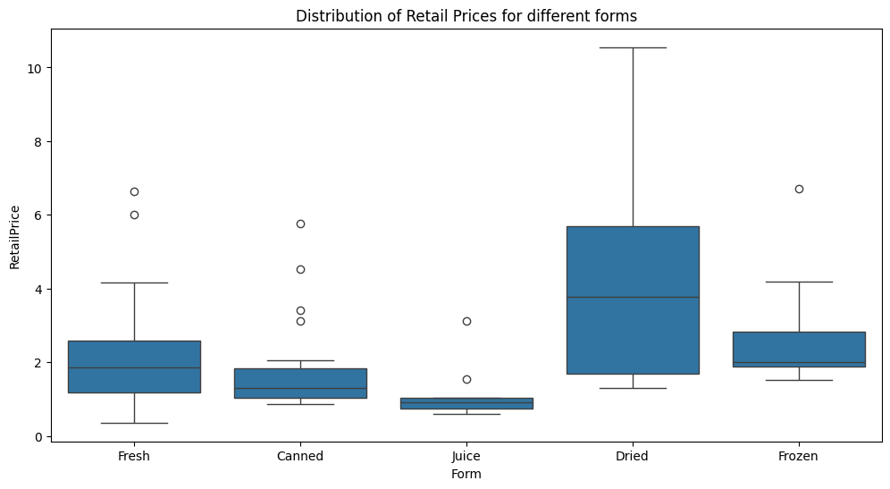

```python
# Question 1
# What is the distribution of Retail Prices for different forms of fruits and vegetables (Fresh, Canned, Juice, Frozen)?
plt.figure(figsize=(12,6))
sb.boxplot(x='Form', y='RetailPrice', data=dataFrame)
plt.title('Distribution of Retail Prices for different forms')
plt.show()
```

Understanding the differences in prices across different forms of food is helpful for knowing consumer preferences, as well as advising the pricing of products. Here, we can see that dried fruits have notably higher retail prices than other forms. On the opposite end, juice is easily the lowest retail price, making it the cheapest and most attractive to consumers. Outliers like these are much easier to notice with this graph.

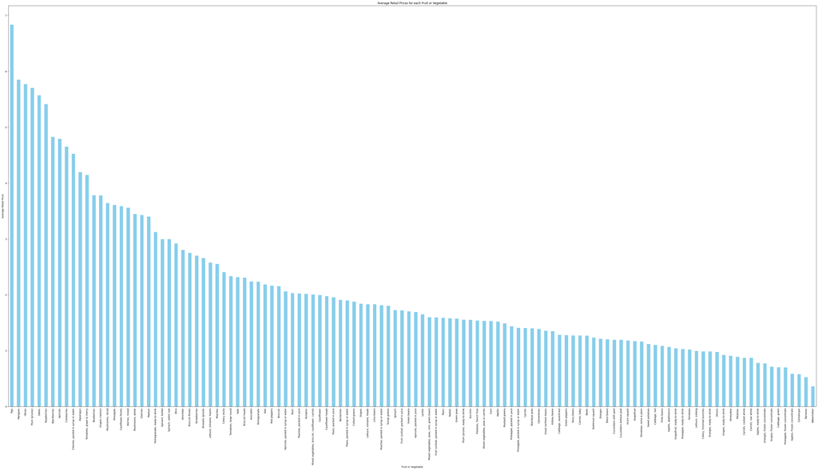

```python
# Question 2
# Which Fruit or Vegetable has the highest & lowest average Retail Prices?
avg_prices = dataFrame.groupby('Fruit or Vegetable')['RetailPrice'].mean().sort_values(ascending=False)
avg_prices.plot(kind='bar', figsize=(60, 30), color='skyblue')
plt.title('Average Retail Prices for each Fruit or Vegetable')
plt.xlabel('Fruit or Vegetable')
plt.ylabel('Average Retail Price')
plt.show()
```

With this bar plot showing the average retail price of each fruit or vegetable, I am hoping to find the highest and lowest retail prices of the food. The data shows that on average, watermelon is cheapest while figs are the most costly. However, we actually find more useful information by seeing every item compared right next to each other, from highest price to lowest. This is very helpful for being able to clearly see from left-to-right the priciest to cheapest foods. This gives a general idea of what fruits or vegetables tend to be more expensive or affordable.

```python
# Question 3
# What is the Cup Equivalent Price for each Fruit or Vegetable?
plt.figure(figsize=(120, 60))
sb.barplot(x='Fruit or Vegetable', y='CupEquivalentPrice', data=dataFrame)
plt.title('Cup Equivalent Price for each Fruit or Vegetable')
plt.xticks(rotation=90)
plt.show()
```

[figure not shown]

This bar plot shows the cup equivalent price for each fruit or vegetable, allowing quick comparison of the cost per cup equivalent of different foods. This is helpful for evaluating how valuable certain foods are compared to others, as we now have a standardized metric to compare prices across different items. We can understand how much each food item is actually valued at by seeing them all with a standardized metric.

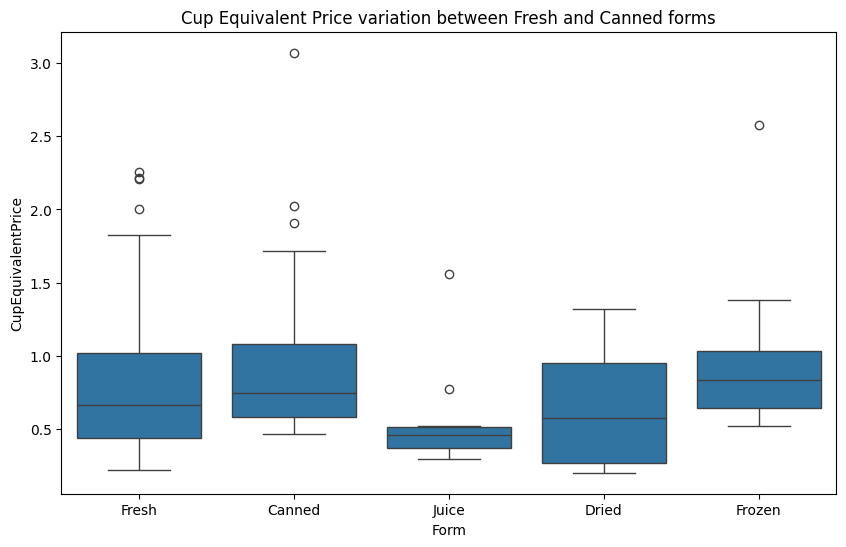

```python
# Question 4
# How does the Cup Equivalent Price vary between fresh & canned forms?
plt.figure(figsize=(10, 6))
sb.boxplot(x='Form', y='CupEquivalentPrice', data=dataFrame)
plt.title('Cup Equivalent Price variation between Fresh and Canned forms')
plt.show()
```

This boxplot shows the variation in cup equivalent prices of forms. We can gain insight by seeing if there is a significant difference in pricing between the forms. Here, there is not much of a notable difference between Fresh & Canned forms. However, we can clearly see a significant difference between them and the juice form. This gives us better understanding of how pricing changes depending on the form of the product.

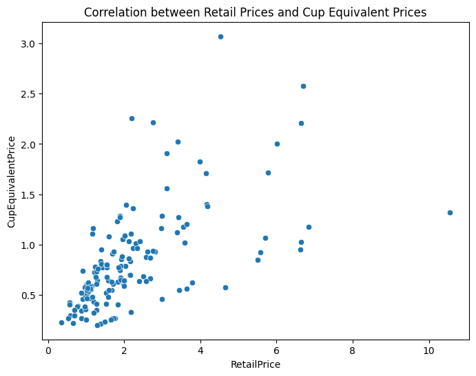

```python
# Question 5
# What is the correlation between Retail Prices & Cup Equivalent Prices?
plt.figure(figsize=(8, 6))
sb.scatterplot(x='RetailPrice', y='CupEquivalentPrice', data=dataFrame)
plt.title('Correlation between Retail Prices and Cup Equivalent Prices')
plt.show()
```

The scatter plot shows the potential correlation between cup equivalent prices & retail prices. This allows us to see if there is a linear relationship between the two variables, giving deeper insight for pricing and if pricing is affected by quantity offered. There appears to be a correlation between the two variables due to how both values scale up together fairly evenly.

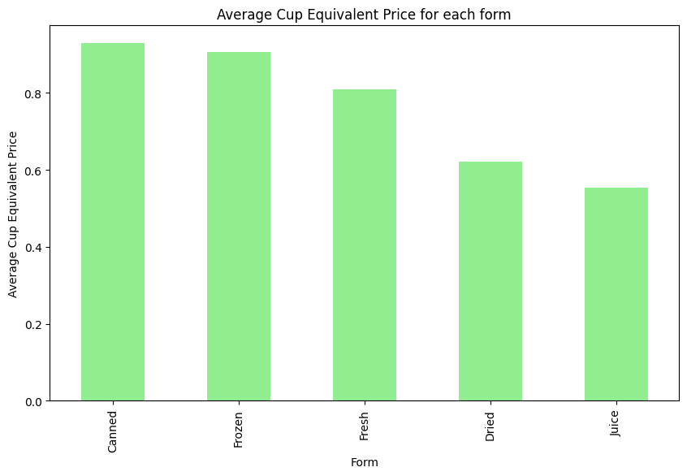

```python
# Question 6
# Which form (Fresh, Canned, Juice, Frozen) has the highest average Cup Equivalent Price?
avg_cup_prices = dataFrame.groupby('Form')['CupEquivalentPrice'].mean().sort_values(ascending=False)
avg_cup_prices.plot(kind='bar', figsize=(10, 6), color='lightgreen')
plt.title('Average Cup Equivalent Price for each form')
plt.xlabel('Form')
plt.ylabel('Average Cup Equivalent Price')
plt.show()
```

This bar plot displays the average cup equivalent price for each form. This helps improve pricing comparisons between specific forms for their average cup equivalent price, giving an easy comparison using a standardized metric. This data also appears to line up with the data displayed in earlier graphs as well.

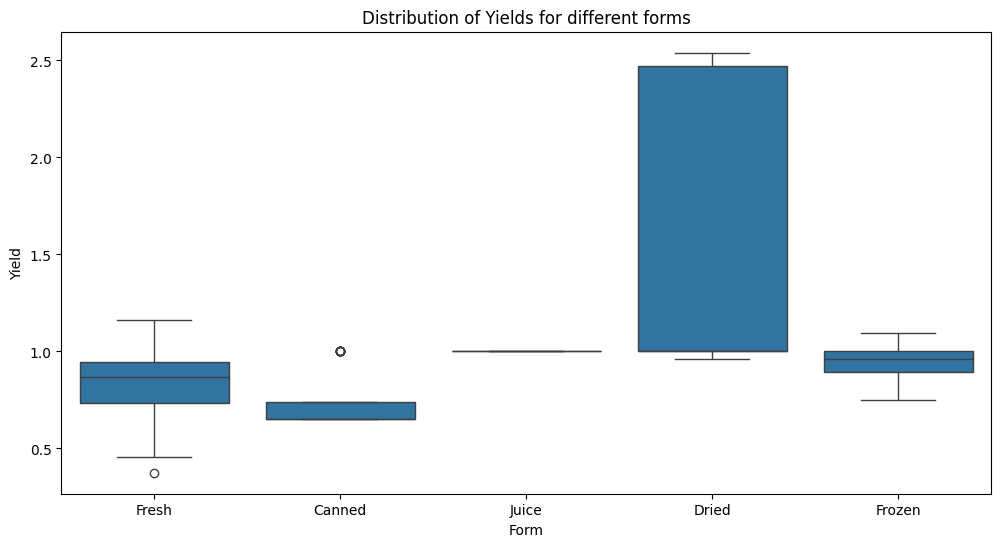

```python
# Question 7
# What is the distribution of Yields for different forms of fruits and vegetables?
plt.figure(figsize=(12, 6))
sb.boxplot(x='Form', y='Yield', data=dataFrame)
plt.title('Distribution of Yields for different forms')
plt.show()
```

The distribution of yields across difference forms can be seen in this box plot. It shows variability in yields within each form, which is beneficial for understanding how efficient different forms are in their yields. Here, the dried form notably has a much bigger range than the other forms, which are all much smaller.

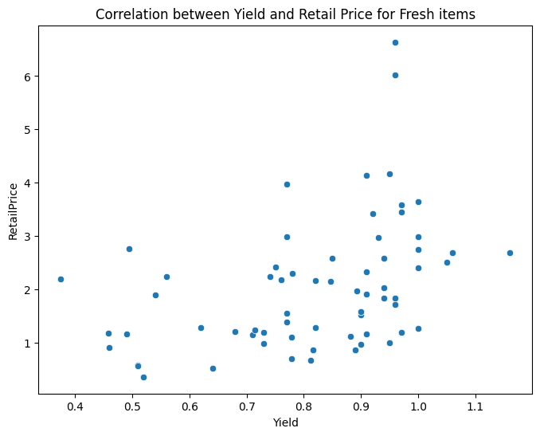

```python
# Question 8
# Is there a correlation between Yield and Retail Price for fresh fruits and vegetables?
freshFrame = dataFrame[dataFrame['Form'] == 'Fresh']
plt.figure(figsize=(8, 6))
sb.scatterplot(x='Yield', y='RetailPrice', data=freshFrame)
plt.title('Correlation between Yield and Retail Price for Fresh items')
plt.show()
```

This scatter plot shows the correlation between yield and retail prices for fresh fruit and vegetables. This allows us to see if there is any relationship between the efficiency of production and retail pricing. However, the values appear to be very scattered without much correlation. From that, I would deduce that there is not a relationship, thus retail prices do not change due to yield and vice versa.

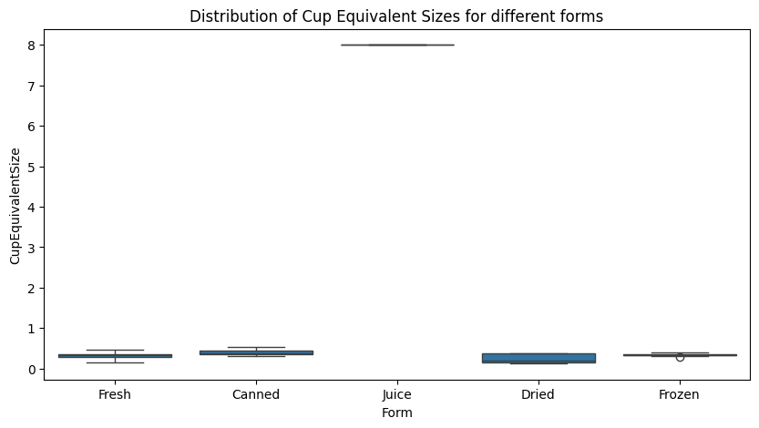

```python
# Question 9
# What is the distribution of Cup Equivalent Sizes for different forms?
plt.figure(figsize=(10, 5))
sb.boxplot(x='Form', y='CupEquivalentSize', data=dataFrame)
plt.title('Distribution of Cup Equivalent Sizes for different forms')
plt.show()
```

This boxplot shows the distribution of cup equivalent sizes across different forms. This helps tell us about the cup sizes offered in each form, which gives us more insight into differences in packaging of different forms. In this graph, we can see that juice is far higher than all of the other forms. This is certainly due to juice being a drink which is consumed much easier and faster than solid foods, which all of the other forms are.

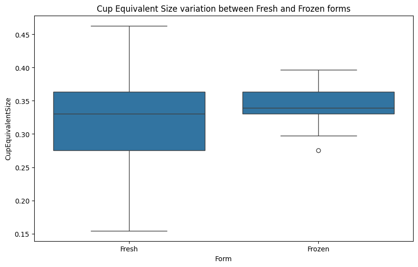

```python
# Question 10
# How does Cup Equivalent Size differ between Fresh and Frozen forms?
freshFrameFrozen = dataFrame[dataFrame['Form'].isin(['Fresh', 'Frozen'])]
plt.figure(figsize=(10, 6))
sb.boxplot(x='Form', y='CupEquivalentSize', data=freshFrameFrozen)
plt.title('Cup Equivalent Size variation between Fresh and Frozen forms')
plt.show()
```

This boxplot shows variation in cup equivalent sizes between Fresh & Frozen forms. This allows us to check if there is any significant difference in cup sizes between the two forms. In real life, this would mean differences in packaging. Fresh fruit has a wider range, while frozen fruit has a smaller range, likely because it is more compact.